# Assignment 04

Sahana Srinivasan and Maria Antonella Pereira

## Visualizing Changes in Labor Market Outcomes for Women in the United States

This document identifies trends in labor market outcomes for women in the United States using data from the Current Population Survey (CPS) from 1980 to 2020. The purpose of these visualizations is to identify potential changes in employment and labor market participation that could be explained by the onset of the COVID-19 pandemic with further research.

Data files and the data dictionary for the CPS can be found [at this link](https://cps.ipums.org/cps/about.shtml).

### Data Cleaning and Setting Up

```r
knitr::opts_chunk$set(echo = TRUE)
knitr::opts_chunk$set(message = FALSE)
knitr::opts_chunk$set(warning = FALSE)
library(srvyr)
tinytex::install_tinytex()
```

```r
def.chunk.hook  <- knitr::knit_hooks$get("chunk")
knitr::knit_hooks$set(chunk = function(x, options) {
  x <- def.chunk.hook(x, options)
  ifelse(options$size != "normalsize", paste0("\n \\", options$size,"\n\n", x, "\n\n \\normalsize"), x)
})
```

```r
#Data Cleaning and Processing
library("ipumsr")
library("tidyverse")
library("dplyr")

#Read data source
ddi <- read_ipums_ddi("cps_00002.xml")
data <- read_ipums_micro(ddi)
```

```
## Use of data from IPUMS CPS is subject to conditions including that users should
## cite the data appropriately. Use command `ipums_conditions()` for more details.
```

```r
data1 <- data %>%
  drop_na(WTFINL)
library(srvyr)

#Assign weights
cps_svy <- as_survey_design(data1, weights = WTFINL)
class(cps_svy)
```

```
## [1] "tbl_svy"        "survey.design2" "survey.design"
```

```r
class(data)
```

```
## [1] "tbl_df"     "tbl"        "data.frame"
```

## **Figure 1: Female Employment Rate (1980 - 2020)**

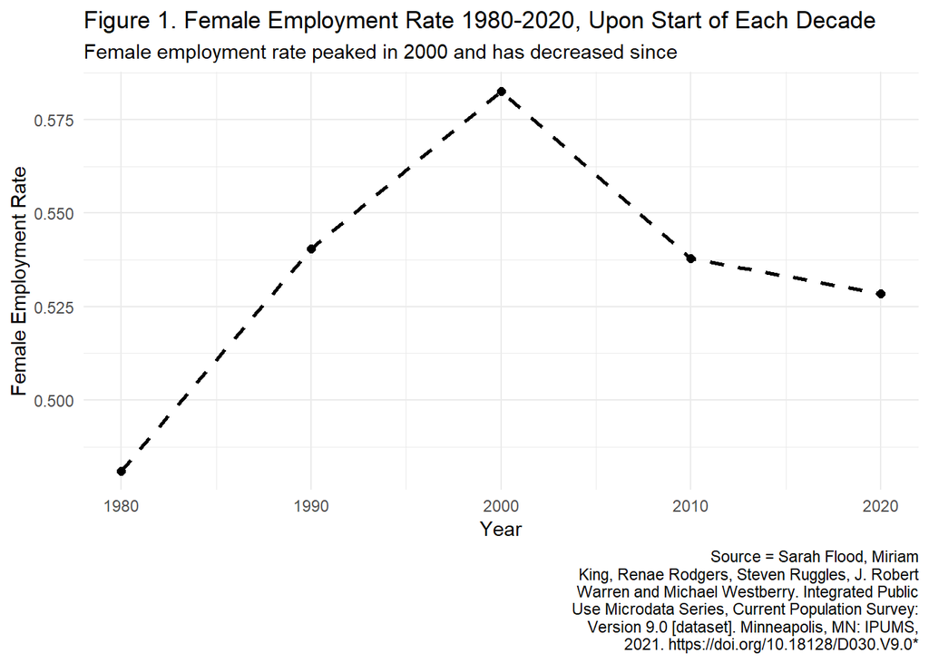

```r
#Figure 1
library("ggplot2")
library("haven")
cps_svy %>%
  #Create dummy variables
  mutate(female = if_else(SEX == 2, 1, 0)) %>%
  mutate(employed = if_else(EMPSTAT == 10 | EMPSTAT == 12, 1, 0)) %>%
  #Filter for working age women
  filter (female == 1,  AGE >= 16) %>%
  #Calculate proportion of employed working age women by year
  group_by(YEAR) %>%
  summarize(
    employed = survey_mean(employed == 1)
  ) %>%
  #Create line graph
  ggplot(mapping = aes(x = YEAR, y = employed)) +
  geom_line(linetype = 2, size = 1) +
  geom_point(size = 2) +
  theme_minimal() +
  labs(
    title = "Figure 1. Female Employment Rate 1980-2020, Upon Start of Each Decade",
    subtitle = "Female employment rate peaked in 2000 and has decreased since",
    x = "Year",
    y = "Female Employment Rate",
    caption = "Source = Sarah Flood, Miriam
    King, Renae Rodgers, Steven Ruggles, J. Robert
    Warren and Michael Westberry. Integrated Public
    Use Microdata Series, Current Population Survey:
    Version 9.0 [dataset]. Minneapolis, MN: IPUMS,
    2021. https://doi.org/10.18128/D030.V9.0*"
    )
```

## **Figure 2: Female Employment by Generation**

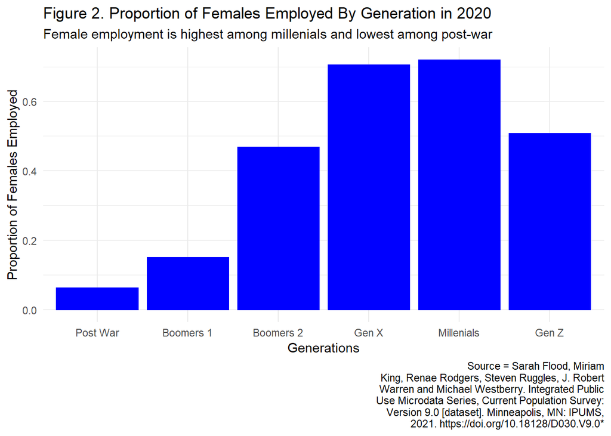

```r
#Figure 2
cps_svy %>%
  #Create variables for analysis
  mutate(female = if_else(SEX == 2, 1, 0)) %>%
  mutate(age_category = case_when( #create variable for generations
    AGE <= 9 ~ "Youth",
    AGE <= 25 ~ "Gen Z" ,
    AGE <= 41 ~ "Millenials",
    AGE <= 57 ~ "Gen X",
    AGE <= 67 ~ "Boomers 2",
    AGE <= 76 ~ "Boomers 1",
    AGE <= 94 ~ "Post War",
    TRUE ~ "WWII"
        )
    ) %>%
  mutate(
    employed = if_else(EMPSTAT == 10 | EMPSTAT == 12, 1, 0)) %>%
  #Filter for working age women 2020
  filter(YEAR == 2020) %>%
  filter(female == 1, AGE >= 16) %>%
  group_by(age_category) %>%
  summarize(
    employed = mean(employed == 1),
  ) %>%
  #Create bar graph
ggplot(mapping = aes(x = age_category, y = employed)) +
geom_col(color = "blue", fill = "blue") +
  scale_x_discrete(limits = c("Post War", "Boomers 1", "Boomers 2", "Gen X", "Millenials", "Gen Z")) +
  theme_minimal() +
   labs(
    title = "Figure 2. Proportion of Females Employed By Generation in 2020",
    subtitle = "Female employment is highest among millenials and lowest among post-war",
    x = "Generations",
    y = "Proportion of Females Employed",
    caption = "Source = Sarah Flood, Miriam
    King, Renae Rodgers, Steven Ruggles, J. Robert
    Warren and Michael Westberry. Integrated Public
    Use Microdata Series, Current Population Survey:
    Version 9.0 [dataset]. Minneapolis, MN: IPUMS,
    2021. https://doi.org/10.18128/D030.V9.0*"
    )
```

## **Figure 3: Average Age of Women not in the Labor Force by Race in 2010 and 2020**

Figure 3 shows the distribution of ages for women not in the labor force disaggregated by race in 2010 and 2020. The average age of non-employed women was higher in 2020 than in 2010 for women of all races. White and Black non-employed women have higher average ages than non-employed women from all other races in both years. Further research should evaluate whether the COVID-19 pandemic exacerbated economic conditions enough that women were largely incentivized to delay the onset of their retirement, thereby increasing the average age of women not in the labor force. Also, further analysis should take into account household income and asset levels for women not in the labor force across all races.

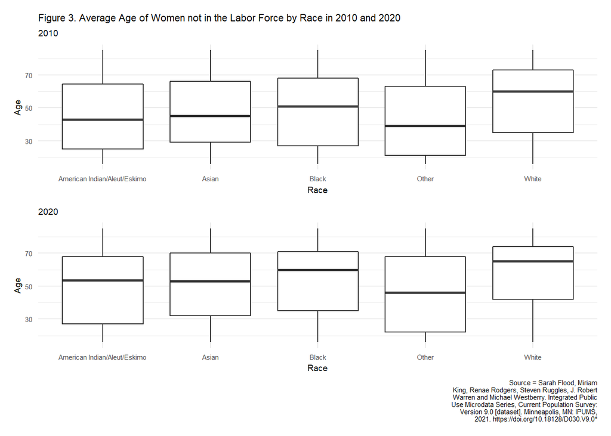

```r
#Figure 3:
boxplot1<- data1%>%
  #Create variables for analysis
mutate(race = case_when(
    RACE == 100 ~ "White",
    RACE == 200 ~ "Black",
    RACE == 300 ~ "American Indian/Aleut/Eskimo",
    RACE == 650 | RACE == 651 ~ "Asian",
    RACE <= 830 | RACE >= 700 ~ "Other")) %>%
  mutate(
    labor_force = if_else(LABFORCE == 2, 1, 0)) %>%
  #Filter for working age women not in labor force in 2010
filter (YEAR == 2010) %>%
filter (SEX == 2, AGE >= 16, labor_force == 0) %>%
  #Create boxplot1
ggplot(mapping = aes( x = race , y = AGE)) +
geom_boxplot() +
  theme_minimal() +
  theme(text=element_text(family="ArialMT", size=7)) +
   labs(
    title = "Figure 3. Average Age of Women not in the Labor Force by Race in 2010 and 2020",
    subtitle = "2010",
    x = "Race",
    y = "Age")


library("patchwork")
boxplot2 <- data1%>%
  #Create variables for analysis
mutate(race = case_when(
    RACE == 100 ~ "White",
    RACE == 200 ~ "Black",
    RACE == 300 ~ "American Indian/Aleut/Eskimo",
    RACE == 650 | RACE == 651 ~ "Asian",
    RACE <= 830 | RACE >= 700 ~ "Other")) %>%
 mutate(
    labor_force = if_else(LABFORCE == 2, 1, 0)) %>%
  #Filter for working age women not in labor force in 2010
filter (YEAR == 2020) %>%
filter (SEX == 2, AGE >= 16, labor_force == 0) %>%
  #Create boxplot2
ggplot(mapping = aes( x = race , y = AGE)) +
geom_boxplot() +
  theme_minimal() +
  theme(text=element_text(family="ArialMT", size=7)) +
   labs(
    subtitle = "2020",
    x = "Race",
    y = "Age",
    caption = "Source = Sarah Flood, Miriam
    King, Renae Rodgers, Steven Ruggles, J. Robert
    Warren and Michael Westberry. Integrated Public
    Use Microdata Series, Current Population Survey:
    Version 9.0 [dataset]. Minneapolis, MN: IPUMS,
    2021. https://doi.org/10.18128/D030.V9.0*"
    )

boxplot1 / boxplot2
```

## **Figure 4: Employment and Non-employment Numbers by Highest Level of Education Completed (2020)**

This graph depicts numbers of employment and non-employment disaggregated by highest level of education attained by 2020. Though a noticeably greater share of those with an elementary or middle school education are non-employed than are employed, the opposite is true among those whose highest level of education is Bachelor’s or Graduate; rates are comparable for those with a high school education. Further analysis should explore the extent to which the COVID-19 pandemic reduced employment opportunities for those with an elementary or middle school education and, conversely, allowed for the retainment of employment opportunities for individuals with a post-secondary degree. Studying the type of employment opportunities lost or gained in 2020 can also elucidate these findings.

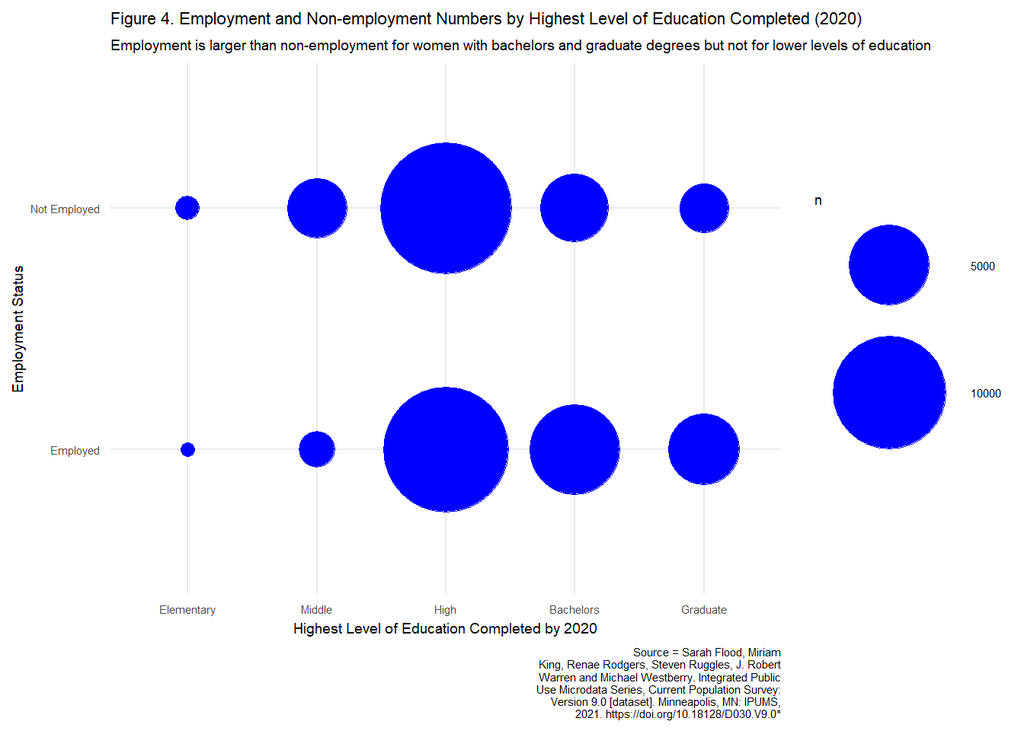

```r
#Visualization 4 -
data1 %>%
  #Create variables for analysis
  mutate(employed = if_else(EMPSTAT == 10 | EMPSTAT == 12, "Employed", "Not Employed")) %>%
  mutate(ed_level = case_when(
    EDUC < 032 & EDUC >= 021 ~ "Elementary",
    EDUC < 070 ~ "Middle",
    EDUC < 100 ~ "High",
    EDUC < 122 ~ "Bachelors",
    EDUC <= 125 ~ "Graduate"
    )) %>%
  #Filter for working age women in 2020
  filter(SEX == 2, AGE >= 16, YEAR == 2020) %>%
  #Create plot
  ggplot(mapping = aes(x = ed_level, y = employed), position = "dodge") +
  geom_count(color = "blue", fill = "blue") +
  scale_size_area(max_size = 30) +
  scale_x_discrete(limits = c("Elementary", "Middle", "High", "Bachelors", "Graduate")) +
  ggtitle("Figure 4. Employment and Non-employment Numbers by Highest Level of Education Completed (2020)") +
  theme_minimal() +
  theme(text=element_text(family="ArialMT", size=7)) +
   labs(
    subtitle = "Employment is larger than non-employment for women with bachelors and graduate degrees but not for lower levels of education",
    x = "Highest Level of Education Completed by 2020",
    y = "Employment Status",
    caption = "Source = Sarah Flood, Miriam
    King, Renae Rodgers, Steven Ruggles, J. Robert
    Warren and Michael Westberry. Integrated Public
    Use Microdata Series, Current Population Survey:
    Version 9.0 [dataset]. Minneapolis, MN: IPUMS,
    2021. https://doi.org/10.18128/D030.V9.0*"
    )
```

### SSH Keys

**Sahana**

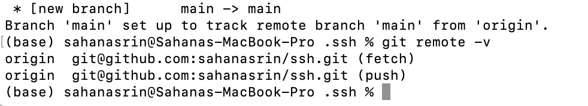

Sahana

**Maria**

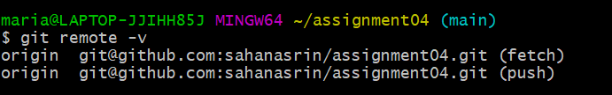

Maria